# Introduction to mlr3

# Intro

**mlr3** is a machine learning framework for R. Together with other packages from the same developers, mostly following the naming scheme "mlr3___", it offers functionality around developing, tuning, and evaluating machine learning workflows.

We will walk through this tutorial interactively. The text is kept short to be followed in real time. There are links to the Appendix for further information that you can read in your spare time.

# Prerequisites

Ensure all packages used in this tutorial are installed. This includes packages from the `mlr3` family, as well as other tools for data handling, cleaning and visualisation which we are going to use. Appendix for more info about packages

```r
# install from CRAN
packages_cran = c(
    "remotes", "magrittr", "data.table", "ggplot2", "skimr", "DataExplorer",
    "OpenML", "rpart.plot", "precrec",
    "glmnet", "kknn", "MASS", "ranger", "xgboost", "e1071",
    "future", "future.apply",
    "mlr3misc", "paradox", "mlr3", "mlr3filter", "mlr3learners")
# install things from GitHub that are not yet on CRAN
packages_gith = c(
    "mlr-org/mlr3tuning", "mlr-org/mlr3pipelines", "mlr-org/mlr3viz")
to_install = setdiff(packages_cran, installed.packages()[,"Package"])
if (length(to_install)) install.packages(to_install)
lapply(packages_gith, remotes::install_github)
```

Load the packages we are going to use:

```r
library("data.table")
library("magrittr")
library("mlr3")
library("mlr3learners")
library("ggplot2")
theme_set(theme_light())
```

# Machine Learning Use Case: German Credit Data

- The German credit data is a research data set of the University of Hamburg from 1994 donated by Prof. Hans Hoffman.
- Description (and manual download) can be found at the [UCI repository](https://archive.ics.uci.edu/ml/datasets/Statlog+%28German+Credit+Data%29).
- Goal: Classify people by their credit risk (**good** or **bad**) using 20 features.

## Importing the data

We use [OpenML](https://www.openml.org) ([R-Package](https://cran.r-project.org/package=OpenML)) to download the data set in a machine-readable format and convert it into a `data.table`:

```r
# load the data set (id 31) from OpenML Library and
# convert the OpenML object to a regular data.table.
# The encapsulate() is important.
credit = mlr3misc::encapsulate("callr", function() {
  data.table::as.data.table(OpenML::getOMLDataSet(data.id = 31))
})$result
```

## Exploring the Data

- We have a look at the data set before we start modeling.
- The `str()` and `summary()` functions gives an overview of features and their type.
- The `skimr` package gives more readable summaries.
- The `DataExplorer` package lets us visualise numeric (`plot_histogram()`) and categorical (`plot_bar()`) data, as well as data relationships.
- Basic things to watch out for:
  - Skewed distributions
  - Missing values
  - Empty / rare factor variables
  - Strongly correlating features (“multicollinearity”)

```r
str(credit)
```

```
#> Classes 'data.table' and 'data.frame':   1000 obs. of  21 variables:
#>  $ checking_status       : Factor w/ 4 levels "<0","0<=X<200",..: 1 2 4 1 1 4 4 2 4 2 ...
#>  $ duration              : num  6 48 12 42 24 36 24 36 12 30 ...
#>  $ credit_history        : Factor w/ 5 levels "no credits/all paid",..: 5 3 5 3 4 3 3 3 3 5 ...
#>  $ purpose               : Factor w/ 11 levels "new car","used car",..: 4 4 7 3 1 7 3 2 4 1 ...
#>  $ credit_amount         : num  1169 5951 2096 7882 4870 ...
#>  $ savings_status        : Factor w/ 5 levels "<100","100<=X<500",..: 5 1 1 1 1 5 3 1 4 1 ...
#>  $ employment            : Factor w/ 5 levels "unemployed","<1",..: 5 3 4 4 3 3 5 3 4 1 ...
#>  $ installment_commitment: num  4 2 2 2 3 2 3 2 2 4 ...
#>  $ personal_status       : Factor w/ 5 levels "male div/sep",..: 3 2 3 3 3 3 3 3 1 4 ...
#>  $ other_parties         : Factor w/ 3 levels "none","co applicant",..: 1 1 1 3 1 1 1 1 1 1 ...
#>  $ residence_since       : num  4 2 3 4 4 4 4 2 4 2 ...
#>  $ property_magnitude    : Factor w/ 4 levels "real estate",..: 1 1 1 2 4 4 2 3 1 3 ...
#>  $ age                   : num  67 22 49 45 53 35 53 35 61 28 ...
#>  $ other_payment_plans   : Factor w/ 3 levels "bank","stores",..: 3 3 3 3 3 3 3 3 3 3 ...
#>  $ housing               : Factor w/ 3 levels "rent","own","for free": 2 2 2 3 3 3 2 1 2 2 ...
#>  $ existing_credits      : num  2 1 1 1 2 1 1 1 1 2 ...
#>  $ job                   : Factor w/ 4 levels "unemp/unskilled non res",..: 3 3 2 3 3 2 3 4 2 4 ...
#>  $ num_dependents        : num  1 1 2 2 2 2 1 1 1 1 ...
#>  $ own_telephone         : Factor w/ 2 levels "none","yes": 2 1 1 1 1 2 1 2 1 1 ...
#>  $ foreign_worker        : Factor w/ 2 levels "yes","no": 1 1 1 1 1 1 1 1 1 1 ...
#>  $ class                 : Factor w/ 2 levels "good","bad": 1 2 1 1 2 1 1 1 1 2 ...
#>  - attr(*, ".internal.selfref")=<externalptr>
```

```r
summary(credit)
```

```
#>     checking_status    duration                           credit_history
#>  <0         :274    Min.   : 4.0   no credits/all paid           : 40
#>  0<=X<200   :269    1st Qu.:12.0   all paid                      : 49
#>  >=200      : 63    Median :18.0   existing paid                 :530
#>  no checking:394    Mean   :20.9   delayed previously            : 88
#>                     3rd Qu.:24.0   critical/other existing credit:293
#>                     Max.   :72.0
#>
#>                 purpose    credit_amount            savings_status      employment
#>  radio/tv           :280   Min.   :  250   <100            :603    unemployed: 62
#>  new car            :234   1st Qu.: 1366   100<=X<500      :103    <1        :172
#>  furniture/equipment:181   Median : 2320   500<=X<1000     : 63    1<=X<4    :339
#>  used car           :103   Mean   : 3271   >=1000          : 48    4<=X<7    :174
#>  business           : 97   3rd Qu.: 3972   no known savings:183    >=7       :253
#>  education          : 50   Max.   :18424
#>  (Other)            : 55
#>  installment_commitment           personal_status      other_parties residence_since
#>  Min.   :1.000          male div/sep      : 50    none        :907   Min.   :1.000
#>  1st Qu.:2.000          female div/dep/mar:310    co applicant: 41   1st Qu.:2.000
#>  Median :3.000          male single       :548    guarantor   : 52   Median :3.000
#>  Mean   :2.973          male mar/wid      : 92                       Mean   :2.845
#>  3rd Qu.:4.000          female single     :  0                       3rd Qu.:4.000
#>  Max.   :4.000                                                       Max.   :4.000
#>
#>          property_magnitude      age        other_payment_plans     housing
#>  real estate      :282      Min.   :19.00   bank  :139          rent    :179
#>  life insurance   :232      1st Qu.:27.00   stores: 47          own     :713
#>  car              :332      Median :33.00   none  :814          for free:108
#>  no known property:154      Mean   :35.55
#>                             3rd Qu.:42.00
#>                             Max.   :75.00
#>
#>  existing_credits                        job      num_dependents  own_telephone
#>  Min.   :1.000    unemp/unskilled non res  : 22   Min.   :1.000   none:596
#>  1st Qu.:1.000    unskilled resident       :200   1st Qu.:1.000   yes :404
#>  Median :1.000    skilled                  :630   Median :1.000
#>  Mean   :1.407    high qualif/self emp/mgmt:148   Mean   :1.155
#>  3rd Qu.:2.000                                    3rd Qu.:1.000
#>  Max.   :4.000                                    Max.   :2.000
#>
#>  foreign_worker  class
#>  yes:963        good:700
#>  no : 37        bad :300
#>
#>
#>
#>
#>
```

```r
skimr::skim(credit)
```

```
#> Skim summary statistics
#>  n obs: 1000
#>  n variables: 21
#>
#> ── Variable type:factor ────────────────────────────────────────────────────────────────────────────────────────────────────────────────────────────────
#>             variable missing complete    n n_unique
#>      checking_status       0     1000 1000        4
#>                class       0     1000 1000        2
#>       credit_history       0     1000 1000        5
#>           employment       0     1000 1000        5
#>       foreign_worker       0     1000 1000        2
#>              housing       0     1000 1000        3
#>                  job       0     1000 1000        4
#>        other_parties       0     1000 1000        3
#>  other_payment_plans       0     1000 1000        3
#>        own_telephone       0     1000 1000        2
#>      personal_status       0     1000 1000        4
#>   property_magnitude       0     1000 1000        4
#>              purpose       0     1000 1000       10
#>       savings_status       0     1000 1000        5
#>                              top_counts ordered
#>    no : 394, <0: 274, 0<=: 269, >=2: 63   FALSE
#>               goo: 700, bad: 300, NA: 0   FALSE
#>    exi: 530, cri: 293, del: 88, all: 49   FALSE
#>   1<=: 339, >=7: 253, 4<=: 174, <1: 172   FALSE
#>                 yes: 963, no: 37, NA: 0   FALSE
#>     own: 713, ren: 179, for: 108, NA: 0   FALSE
#>   ski: 630, uns: 200, hig: 148, une: 22   FALSE
#>       non: 907, gua: 52, co : 41, NA: 0   FALSE
#>      non: 814, ban: 139, sto: 47, NA: 0   FALSE
#>               non: 596, yes: 404, NA: 0   FALSE
#>    mal: 548, fem: 310, mal: 92, mal: 50   FALSE
#>  car: 332, rea: 282, lif: 232, no : 154   FALSE
#>  rad: 280, new: 234, fur: 181, use: 103   FALSE
#>   <10: 603, no : 183, 100: 103, 500: 63   FALSE
#>
#> ── Variable type:numeric ───────────────────────────────────────────────────────────────────────────────────────────────────────────────────────────────
#>                variable missing complete    n    mean      sd  p0    p25    p50     p75
#>                     age       0     1000 1000   35.55   11.38  19   27     33     42
#>           credit_amount       0     1000 1000 3271.26 2822.74 250 1365.5 2319.5 3972.25
#>                duration       0     1000 1000   20.9    12.06   4   12     18     24
#>        existing_credits       0     1000 1000    1.41    0.58   1    1      1      2
#>  installment_commitment       0     1000 1000    2.97    1.12   1    2      3      4
#>          num_dependents       0     1000 1000    1.16    0.36   1    1      1      1
#>         residence_since       0     1000 1000    2.85    1.1    1    2      3      4
#>   p100     hist
#>     75 ▇▇▆▃▂▁▁▁
#>  18424 ▇▃▂▁▁▁▁▁
#>     72 ▇▅▅▃▁▁▁▁
#>      4 ▇▁▅▁▁▁▁▁
#>      4 ▂▁▃▁▁▂▁▇
#>      2 ▇▁▁▁▁▁▁▂
#>      4 ▂▁▆▁▁▃▁▇
```

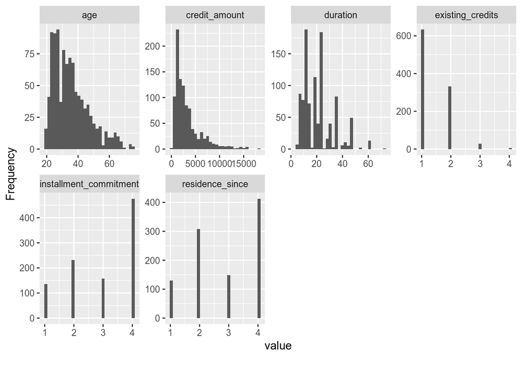

```r
DataExplorer::plot_histogram(credit)
```

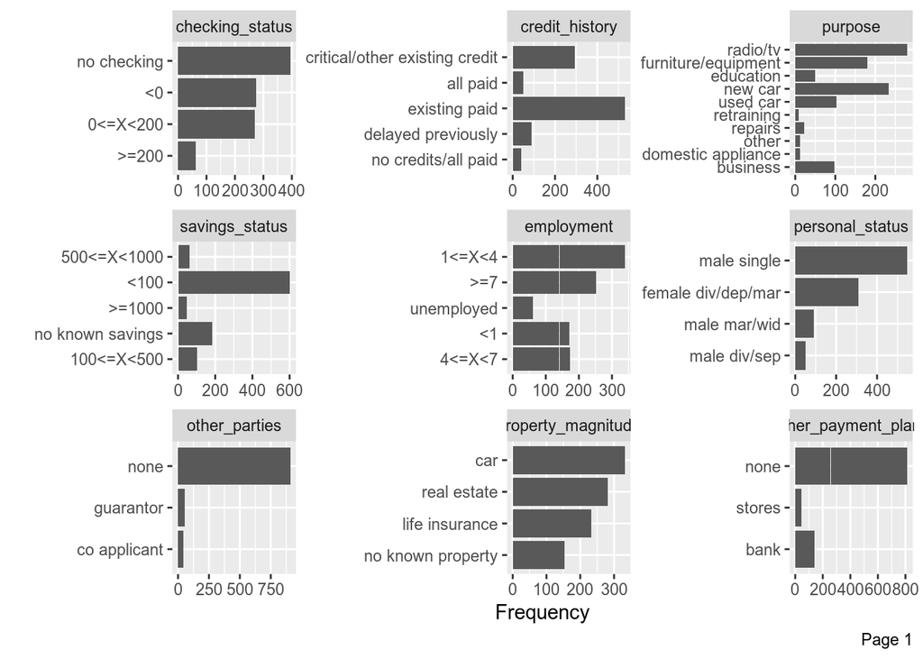

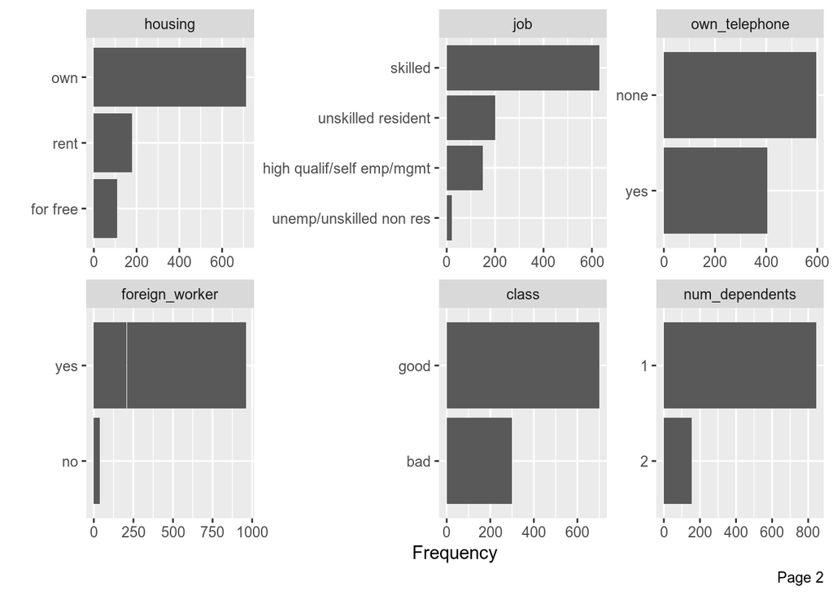

```r
DataExplorer::plot_bar(credit)
```

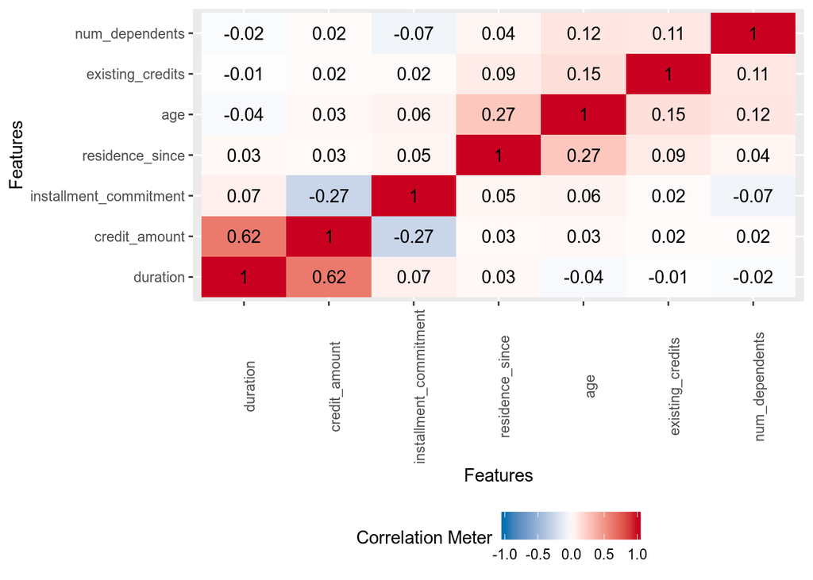

```r
DataExplorer::split_columns(credit) %$%
  DataExplorer::plot_correlation(continuous)
```

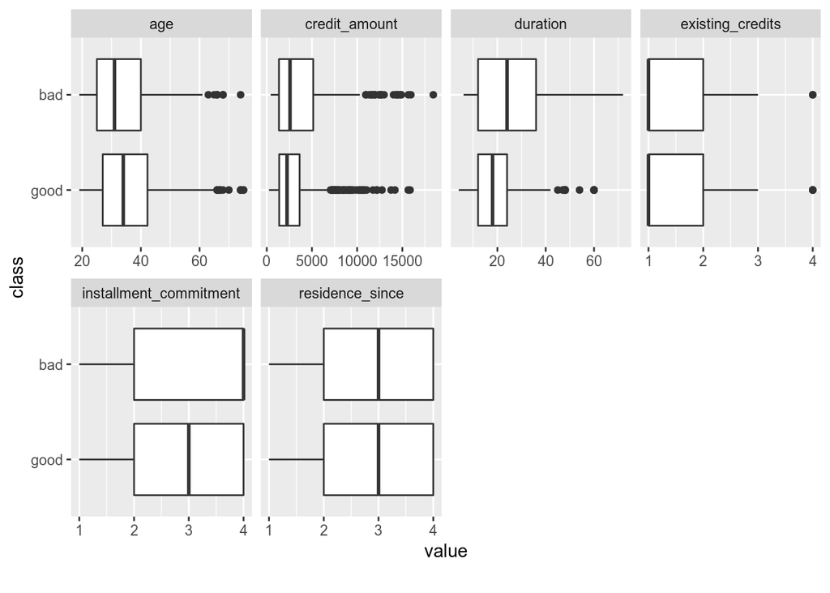

```r
DataExplorer::plot_boxplot(credit, by = "class")
```

- We have empty factor levels, so we drop them:

```r
credit %<>% droplevels()
```

# Modeling

Considering how we are going to tackle the problem relates closely to what `mlr3` entities we will use.

- What is the problem we are trying to solve?
  - i.e. what **Task** do we use?
  - Binary classification.
  - $\Rightarrow$ We use `TaskClassif`.
- What are appropriate learning algorithms?
  - i.e. what **Learner** do we use?
  - Logistic regression, CART, Random Forest
  - $\Rightarrow$ `lrn("classif.log_reg")`, `lrn("classif.rpart")`, `lrn("classif.ranger")`
- How do we evaluate “good” performance? $\Rightarrow$ Depends on many things! Cost of false positive vs. false negative, legal requirements, …
  - i.e. what **Measure** do we use?
  - We start with misclassification error (simle!) and will also consider AUC.
  - $\Rightarrow$ `msr("classif.ce")`, `msr("classif.auc")`

## Task Definition

- We need to consider what the name of the target variable is: `"class"`.

```r
task = TaskClassif$new("GermanCredit", credit, "class")
```

## Model Fitting: Logistic Regression

- Get the `Learner` from the database. It is provided by `mlr3learners` and uses R’s `glm()` function.

```r
learner_logreg = lrn("classif.log_reg")
```

- Model fitting is easy

```r
learner_logreg$train(task)
```

- Inspecting the model. It is the result returned by `glm()` and can be inspected as such.

```r
coefficients = learner_logreg$model %>% summary() %$%
  as.data.table(coefficients, keep.rownames = TRUE)
coefficients[order(`Pr(>|z|)`)] %>% head(n = 10) %>% print(digits = 3)
```

```
#>                                               rn  Estimate Std. Error z value Pr(>|z|)
#>  1:                   checking_statusno checking -1.711888   2.32e-01   -7.37 1.66e-13
#>  2:                              purposeused car -1.666467   3.74e-01   -4.45 8.51e-06
#>  3:                       installment_commitment  0.330090   8.83e-02    3.74 1.85e-04
#>  4:                              purposeradio/tv -0.891583   2.47e-01   -3.61 3.08e-04
#>  5:               savings_statusno known savings -0.946689   2.62e-01   -3.61 3.10e-04
#>  6: credit_historycritical/other existing credit -1.435772   4.40e-01   -3.26 1.10e-03
#>  7:                   purposefurniture/equipment -0.791610   2.61e-01   -3.03 2.42e-03
#>  8:                                     duration  0.027863   9.30e-03    3.00 2.72e-03
#>  9:                                credit_amount  0.000128   4.44e-05    2.89 3.89e-03
#> 10:                      other_payment_plansnone -0.646329   2.39e-01   -2.70 6.87e-03
```

## Model Fitting: Decision Tree

- Same procedure as before
- We fit a decision tree with depth 3 for nicer plots

```r
learner_cart = lrn("classif.rpart", maxdepth = 3)
learner_cart$train(task)
```

- The `rpart.plot` library gives expressive plots:

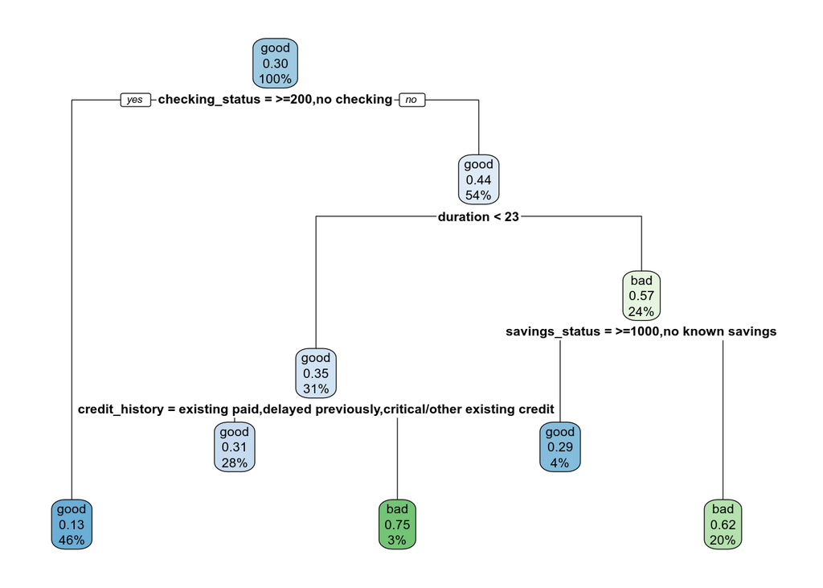

```r
rpart.plot::rpart.plot(learner_cart$model)
```

## Model Fitting: Random Forest

```r
learner_rf = lrn("classif.ranger", importance = "impurity")
learner_rf$train(task)
```

```r
learner_rf$importance()
```

```
#>          credit_amount        checking_status                    age
#>              55.023916              47.062750              43.147626
#>               duration                purpose         credit_history
#>              41.220088              25.116997              24.733077
#>             employment         savings_status     property_magnitude
#>              21.368195              20.082949              18.941929
#> installment_commitment        residence_since        personal_status
#>              17.410324              16.753125              15.301674
#>                    job    other_payment_plans                housing
#>              13.312583              11.511337              10.598417
#>       existing_credits          own_telephone          other_parties
#>               9.242539               8.207242               8.004813
#>         num_dependents         foreign_worker
#>               5.778569               1.798239
```

- We convert the importance into a `data.table` so we can plot it

```r
importance = as.data.table(learner_rf$importance(), keep.rownames = TRUE)
colnames(importance) = c("Feature", "Importance")
importance
```

```
#>                    Feature Importance
#>  1:          credit_amount  55.023916
#>  2:        checking_status  47.062750
#>  3:                    age  43.147626
#>  4:               duration  41.220088
#>  5:                purpose  25.116997
#>  6:         credit_history  24.733077
#>  7:             employment  21.368195
#>  8:         savings_status  20.082949
#>  9:     property_magnitude  18.941929
#> 10: installment_commitment  17.410324
#> 11:        residence_since  16.753125
#> 12:        personal_status  15.301674
#> 13:                    job  13.312583
#> 14:    other_payment_plans  11.511337
#> 15:                housing  10.598417
#> 16:       existing_credits   9.242539
#> 17:          own_telephone   8.207242
#> 18:          other_parties   8.004813
#> 19:         num_dependents   5.778569
#> 20:         foreign_worker   1.798239
```

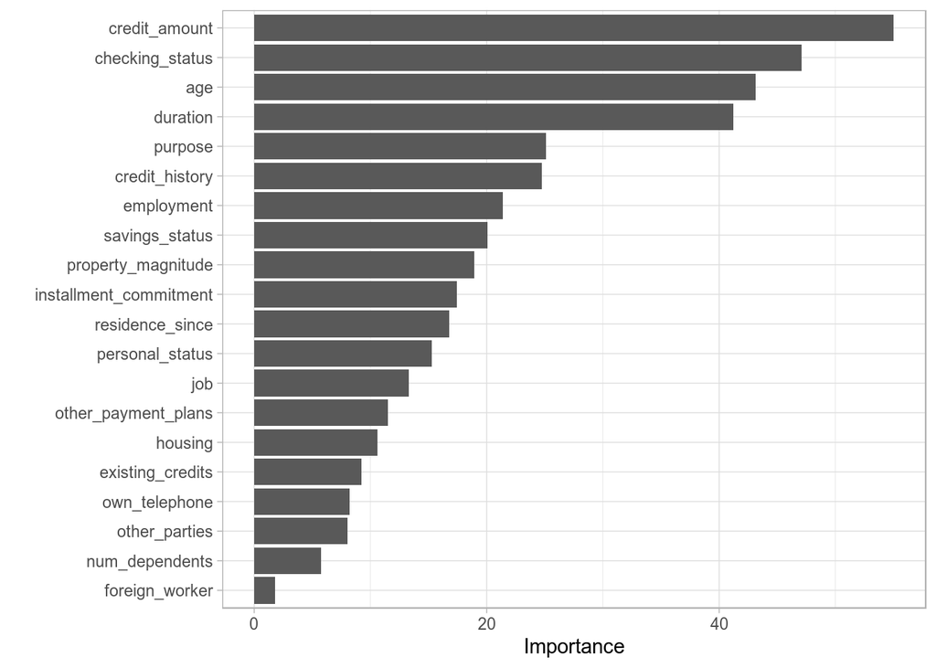

```r
ggplot(importance, aes(x = reorder(Feature, Importance), y = Importance)) +
  geom_col() + coord_flip() + xlab("")
```

## Model Fitting: Other Models

Feel free to experiment with other `Learner`s! There are many `Learner`s defined in `mlr_learners`. You need to load the `mlr3learners` package to get access to most of them.

Use `?mlr_learners_xxx` or `help(class(lrn("xxx"))[1])` to see the help page, or use [the internet](https://mlr3learners.mlr-org.com/reference/index.html).

```r
mlr_learners
```

```
#> <DictionaryLearner> with 21 stored values
#> Keys: classif.debug, classif.featureless, classif.glmnet, classif.kknn,
#>   classif.lda, classif.log_reg, classif.naive_bayes, classif.qda,
#>   classif.ranger, classif.rpart, classif.svm, classif.xgboost, regr.featureless,
#>   regr.glmnet, regr.kknn, regr.km, regr.lm, regr.ranger, regr.rpart, regr.svm,
#>   regr.xgboost
```

# Prediction

- A model, once trained, can be used to predict outcomes from new data.
- This new data needs to be loaded as a `Task` as well, then the `Learner`’s `$predict()` function can be used.
- We simulate new data by sampling from the credit data. No need to pay close attention what is going on here.

```r
newdata = as.data.table(lapply(credit, sample, size = 3, replace = TRUE))
# we need to set the 'class' column to 'NA', otherwise mlr3 thinks this is the
# actual outcome. This is desirable for performance evaluation, but not here.
newdata$class[1:3] = NA
```

```r
new_task = TaskClassif$new("new_credit", newdata, "class", positive = "good")
```

- Let’s see what the models predict

```r
learner_logreg$predict(new_task)
```

```
#> <PredictionClassif> for 3 observations:
#>  row_id truth response
#>       1  <NA>     good
#>       2  <NA>     good
#>       3  <NA>      bad
```

```r
learner_cart$predict(new_task)
```

```
#> <PredictionClassif> for 3 observations:
#>  row_id truth response
#>       1  <NA>     good
#>       2  <NA>     good
#>       3  <NA>      bad
```

```r
learner_rf$predict(new_task)
```

```
#> <PredictionClassif> for 3 observations:
#>  row_id truth response
#>       1  <NA>      bad
#>       2  <NA>     good
#>       3  <NA>     good
```

- They may disagree, but which do we trust most? We should do Performance Evaluation and benchmarks!

## Probability Prediction

- Learners may not only predict a class variable (“response”), but also their degree of “belief” / uncertainty in a given response.
- We achieve this by setting the `$predict_type` slot to `"prob"`.
- Sometimes this needs to be done *before* the learner is trained.
- Can alternatively construct with this: `lrn("classif.log_reg", predict_type = "prob")`

```r
learner_logreg$predict_type = "prob"
```

```r
learner_logreg$predict(new_task)
```

```
#> <PredictionClassif> for 3 observations:
#>  row_id truth response prob.good  prob.bad
#>       1  <NA>     good 0.6877390 0.3122610
#>       2  <NA>     good 0.7727115 0.2272885
#>       3  <NA>      bad 0.4500287 0.5499713
```

- Careful when interpreting this as probabilities!

# Performance Evaluation

## The Hard way

To show what is happening behind the scenes we will do one round of resampling ourselves 1. Decide on a train/test split.

```r
train_set = sample(nrow(credit), size = nrow(credit) * 2/3)
test_set = setdiff(seq_len(nrow(credit)), train_set)
head(train_set)  # rows of the dataset to use for training
```

```
#> [1] 820 797 406 183 748 720
```

2. Fit a model. We choose to use the `"classif.rpart"` model. The `row_ids` argument of the `$train()` function lets us train on a subset of the data.

```r
learner_cart$train(task, row_ids = train_set)
```

3. Make a prediction on the `test_set` rows.

```r
prediction = learner_cart$predict(task, row_ids = test_set)
```

```r
prediction
```

```
#> <PredictionClassif> for 334 observations:
#>     row_id truth response
#>          3  good     good
#>          9  good     good
#>         15  good     good
#> ---
#>        993  good     good
#>        998  good     good
#>        999   bad      bad
```

We now want to know how good the prediction matches reality. We can either compare `prediction$truth` and `prediction$response` manually, or use the `msr("classif.ce")` misclassification rate measure.

```r
# manual
mean(prediction$truth != prediction$response)
```

```
#> [1] 0.245509
```

```r
# more scalable and less errorprone: Using a msr()
prediction$score(msr("classif.ce"))
```

```
#> classif.ce
#>   0.245509
```

```r
# actually, "classif.ce" is the default measure for classification:
prediction$score()
```

```
#> classif.ce
#>   0.245509
```

## The Easy Way

- What we just did was “holdout” resampling.
- `mlr3` lets us do that, and other resampling schemes, automatically.
- Get the resampling scheme as `rsmp()`:

```r
resampling = rsmp("holdout")
print(resampling)
```

```
#> <ResamplingHoldout> with 1 iterations
#> * Instantiated: FALSE
#> * Parameters: ratio=0.6667
```

- We use `resample()` to do the resampling calculation, and `$aggregate()` to learn the score.

```r
resres = resample(task, learner_logreg, resampling)
```

```r
resres$aggregate()
```

```
#> classif.ce
#>  0.2672673
```

- The good thing is we can easily do differend kinds of resampling. E.g. repeated holdout (`"subsampling"`), or cross validation. We can also use different scores.
- Most methods do repeated train/predict cycles on different data subsets and aggregate the result (usualy as the `mean()`). Doing this manually would require us to write loops.

```r
resample(task, learner_logreg, rsmp("subsampling", repeats = 10))$aggregate()
```

```
#> classif.ce
#>   0.251952
```

```r
resample(task, learner_logreg, rsmp("cv", folds = 10))$aggregate()
```

```
#> classif.ce
#>      0.257
```

```r
# false positive and false negative rate
resample(task, learner_logreg, rsmp("cv", folds = 10))$aggregate(list(
  msr("classif.fpr"),
  msr("classif.fnr")
))
```

```
#> classif.fpr classif.fnr
#>   0.5012772   0.1326938
```

## Performance Evaluation: Outlook

There are a few more resampling methods, and quite a few more measures. List them in

```r
mlr_resamplings
```

```
#> <DictionaryResampling> with 6 stored values
#> Keys: bootstrap, custom, cv, holdout, repeated_cv, subsampling
```

```r
mlr_measures
```

```
#> <DictionaryMeasure> with 31 stored values
#> Keys: classif.acc, classif.auc, classif.ce, classif.costs, classif.dor,
#>   classif.f_score, classif.fdr, classif.fn, classif.fnr, classif.for,
#>   classif.fp, classif.fpr, classif.npv, classif.ppv, classif.precision,
#>   classif.recall, classif.sensitivity, classif.specificity, classif.tn,
#>   classif.tnr, classif.tp, classif.tpr, debug, oob_error, regr.mae, regr.mse,
#>   regr.rmse, selected_features, time_both, time_predict, time_train
```

To get help on a resampling method, use `?mlr_resamplings_xxx`, for a measure do `?mlr_measures_xxx`. you can also use the [mlr3 reference](https://mlr3.mlr-org.com/reference/index.html) online.

Some measure, for example `"auc"`, require a “probability” prediction, instead of a response prediction, see **Probability Prediction**.

# Performance Comparison and Benchmarks

- We could compare `Learners` by evaluating `resample()` for each of them manually.
- `benchmark()` automatically performs resampling evaluations.
- Create fully crossed designs using `benchmark_grid()`: multiple `Learner`s **x** multiple `Task`s **x** multiple `Resampling`s

```r
bm_design = benchmark_grid(task = task, resamplings = rsmp("cv", folds = 10),
  learners = list(
      lrn("classif.log_reg", predict_type = "prob"),
      lrn("classif.rpart", predict_type = "prob"),
      lrn("classif.ranger", predict_type = "prob")
  ))
```

- Careful, large benchmarks may take a long time! This one should take less than a minute, however.
- In General, we want use *parallelization* to speed things up on multicore machines.

```r
future::plan("multiprocess")
bmr = benchmark(bm_design)
```

- We can compare different measures. We compare misclassification rate and AUC.

```r
performances = bmr$aggregate(list(msr("classif.ce"), msr("classif.auc")))
performances[, c("learner_id", "classif.ce", "classif.auc")]
```

```
#>         learner_id classif.ce classif.auc
#> 1: classif.log_reg      0.243   0.7853896
#> 2:   classif.rpart      0.261   0.7231649
#> 3:  classif.ranger      0.228   0.8010796
```

# Outlook

- How did we do? We can check the [OpenML](https://www.openml.org/t/31) website for performances of other machine learning methods.
  - We see `ranger` is among the top methods
- Things we have not done that should be considered:
  - We have worked with default hyperparameters, but we may want to see if tuning them helps (Day 2)
  - Some preprocessing and feature extraction steps may sometimes be helpful (Day 3)

# Appendix

## R Pro Tips

- What are the arguments of `lrn()`, `tsk()`, etc. again? -> Think about the corresponding dictionary

```r
mlr_learners
```

```
#> <DictionaryLearner> with 21 stored values
#> Keys: classif.debug, classif.featureless, classif.glmnet, classif.kknn,
#>   classif.lda, classif.log_reg, classif.naive_bayes, classif.qda,
#>   classif.ranger, classif.rpart, classif.svm, classif.xgboost, regr.featureless,
#>   regr.glmnet, regr.kknn, regr.km, regr.lm, regr.ranger, regr.rpart, regr.svm,
#>   regr.xgboost
```

```r
mlr_tasks
```

```
#> <DictionaryTask> with 9 stored values
#> Keys: boston_housing, german_credit, iris, mtcars, pima, sonar, spam, wine, zoo
```

```r
mlr_measures
```

```
#> <DictionaryMeasure> with 31 stored values
#> Keys: classif.acc, classif.auc, classif.ce, classif.costs, classif.dor,
#>   classif.f_score, classif.fdr, classif.fn, classif.fnr, classif.for,
#>   classif.fp, classif.fpr, classif.npv, classif.ppv, classif.precision,
#>   classif.recall, classif.sensitivity, classif.specificity, classif.tn,
#>   classif.tnr, classif.tp, classif.tpr, debug, oob_error, regr.mae, regr.mse,
#>   regr.rmse, selected_features, time_both, time_predict, time_train
```

```r
mlr_resamplings
```

```
#> <DictionaryResampling> with 6 stored values
#> Keys: bootstrap, custom, cv, holdout, repeated_cv, subsampling
```

- What are the arguments of a `$new()` constructor?

```r
formals(TaskClassif$public_methods$initialize)
```

- What are the possible slots and functions of an object?

```r
# Writing `prediction$`, and pressing <TAB> should work.
# Otherwise:
names(prediction)
```

```
#>  [1] ".__enclos_env__" "missing"         "confusion"       "prob"
#>  [5] "response"        "truth"           "row_ids"         "predict_types"
#>  [9] "task_type"       "data"            "set_threshold"   "initialize"
#> [13] "clone"           "score"           "print"           "format"
```

```r
# try names without `()` first
# and see if it is a function
```

- How do I see the help file of an object

```r
# The documentation is organized by object classes
class(prediction)
```

```
#> [1] "PredictionClassif" "Prediction"        "R6"
```

```r
# use ?PredictionClassif, ?Prediction etc.
# Try all elements listed in the class
```

## mlr3 and its Extensions

| Package | Functionality |
| --- | --- |
| `mlr3` | Framework for machine learning: `Task`, `Learner`, `resample()` and `benchmark()` |
| `mlr3learners` | Concrete `Learner`s for many popular machine learning implementations |
| `mlr3pipelines` | Dataflow programming of machine learning workflows. |
| `mlr3tuning` | Hyperparameter tuning for machine learning algorithms. |
| `mlr3filter` | Feature filtering |
| `mlr3viz` | Visualisations and plots |
| `paradox` | Auxiliary package providing (hyper)parameter handling |
| `mlr3misc` | Auxiliary functions |

## Packages

The non-`mlr3` packages we use:

[output not shown]